# R Workshop, Part 2: Analyzing a Dataset

Natalia Vélez, Yuan Chang Leong

6/25/2017

This part of the workshop is intended to give you a more realistic experience of analyzing a new dataset. You’ll do all of the steps we covered in part 1—load and checking datasets, creating summaries, plotting data, and running statistics—mostly on your own. Of course, you are welcome to ask for help whenever you get stuck!

## Your dataset

(Note: When you write R Markdown files to analyze your own datasets, it’s good practice to describe what information your variables contain, and to start off the file by loading your data and libraries.)

```r
# Load libraries
library(dplyr)
```

```r
library(tidyr)
library(ggplot2)
library(ggthemes)
library(RColorBrewer)
library(lme4)
df_survey = read.csv('http://stanford.edu/class/psych252/data/fieldsimul1.csv')
```

Let’s explore this data a bit to see what we’ll be working with:

```r
str(df_survey)
```

```
## 'data.frame':    200 obs. of  7 variables:
##  $ recall : int  1 1 1 1 1 1 1 1 1 1 ...
##  $ prop54 : int  1 1 1 1 1 1 1 1 1 1 ...
##  $ party  : int  1 1 1 1 1 1 1 1 1 1 ...
##  $ age    : int  49 44 46 50 25 28 21 20 22 73 ...
##  $ optmism: int  7 8 7 7 6 7 5 5 6 8 ...
##  $ agecat : int  45 45 45 45 24 24 24 24 24 70 ...
##  $ recallq: int  1 1 1 1 1 1 1 1 1 1 ...
```

```r
head(df_survey)
```

```
##   recall prop54 party age optmism agecat recallq
## 1      1      1     1  49       7     45       1
## 2      1      1     1  44       8     45       1
## 3      1      1     1  46       7     45       1
## 4      1      1     1  50       7     45       1
## 5      1      1     1  25       6     24       1
## 6      1      1     1  28       7     24       1
```

```r
summary(df_survey)
```

```
##      recall         prop54          party           age
##  Min.   :1.00   Min.   :1.000   Min.   :1.00   Min.   :20.00
##  1st Qu.:1.00   1st Qu.:1.000   1st Qu.:1.00   1st Qu.:37.00
##  Median :1.00   Median :2.000   Median :2.00   Median :48.00
##  Mean   :1.51   Mean   :1.785   Mean   :1.75   Mean   :48.32
##  3rd Qu.:2.00   3rd Qu.:2.000   3rd Qu.:2.00   3rd Qu.:58.00
##  Max.   :3.00   Max.   :3.000   Max.   :3.00   Max.   :75.00
##     optmism           agecat         recallq
##  Min.   : 0.000   Min.   :24.00   Min.   :-1.000
##  1st Qu.: 4.000   1st Qu.:35.00   1st Qu.:-1.000
##  Median : 6.000   Median :45.00   Median : 1.000
##  Mean   : 5.615   Mean   :48.12   Mean   : 0.115
##  3rd Qu.: 7.000   3rd Qu.:57.00   3rd Qu.: 1.000
##  Max.   :11.000   Max.   :70.00   Max.   : 1.000
```

Here we can see that this **dataframe** is composed of 7 **variables** that each has 200 observations. In this case, each observation represents a different participant, and the 7 variables tell us information about that participant.

**Exercise:** As an example, let’s look at all the information for participant 5 by looking at the 5th row of df_survey:

```r
# FILL IN CODE HERE
```

This shows us that participant 5 is 25 years old, and has an optimism score of 6.

## If you learn nothing else today, learn this: Search!

We’ll keep reminding you of this throughout today’s workshop: search quickly, search often, and search in plain English (or your preferred non-computer language)!

### Use the internet!

Don’t know what function you should use to do a t-test? Google “t test R”, or “how do I do a t-test in R?”. Don’t remember how to use the chisq.test() function? Google “chisq.test() R”. Don’t remember what a chi-squared test is? Google it, and read the Wikipedia page, and the Stackexchange discussion, and whatever weird PDFs you find online. Still getting an error message when you try to run the code? Google that error message, in quotes.

Every person using R, and every person doing statistics, has a million questions as they are doing it - novices and experts alike. Luckily for all of us, many of our fellow R and stats learners post their questions online, and other lovely people attempt to answer them publicly! We read somewhere that a prominent distinction between an experienced programmer and a novice is the longer latency for the novice to look up the help for something confusing (but the direction of causality is not clear!).

### Use R!

Another wonderful thing about working in R is that there’s actually a lot of help built right into R, and RStudio makes it very easy to see. Almost all R functions (more later on what those are) have help files built in that will provide you with useful information about what those functions do and how to use them. You find this by typing ‘?function’, where I am using “function” as a stand-in for the name you actually want to know about (e.g., ‘?chisq.test’ or ‘?t.test’). It’s important to read these files closely the first time you encounter a function, but it’s also (possibly more) important to refer to them **frequently**. If you have a sense for what you want to do, but don’t know or can’t remember the exact function that will do it, you can use two question marks to search through the help files for a term (e.g. ‘??regression’).

### Debugging practice

Here are several chunks of code that are broken. Fix them! What tools are available to help you use to do this? We’ve included a note under each chunk about what we were **trying** to do :).

Note: you need to uncomment (remove the #) the commented lines, otherwise they won’t run.

**Exercise 1:** Get the last element of x

```r
x = 25:90
#x[90,]
```

**Exercise 2:** Create a scatter plot of responses to the recall question by age

```r
#ggplot(data=df_survey, aesthetic(x = age, y = recallq)) +
#  geom_point()
```

**Exercise 3:** Here’s a more general problem you will run into, simply, how to do something you’ve never done before! Search google and figure out how to plot a **polynomial** regression line (e.g. y = x^2) onto this ggplot code:

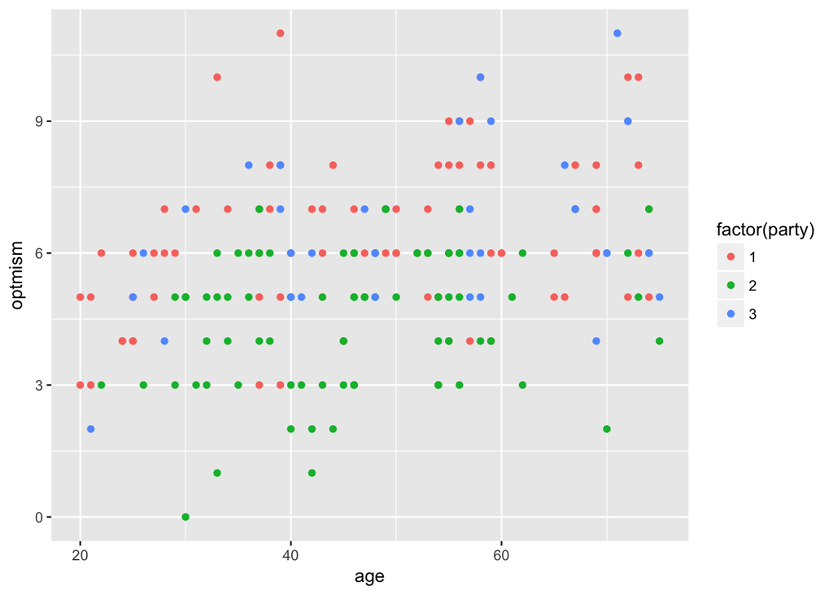

```r
ggplot(data = df_survey, aes(x = age, y = optmism, color = factor(party))) +
  geom_point()
```

## Cleaning up data

As in part 1, we’ll use `dplyr` to clean up our data. In part 1, you learned about the functions `mutate`, `group_by` and `summarise`; in this part, you’ll learn about a few other useful things that dplyr can do.

First, let’s use `mutate` again. If we look at a summary of our dataset, you’ll see that every single variable is coded as an integer:

```r
str(df_survey)
```

```
## 'data.frame':    200 obs. of  7 variables:
##  $ recall : int  1 1 1 1 1 1 1 1 1 1 ...
##  $ prop54 : int  1 1 1 1 1 1 1 1 1 1 ...
##  $ party  : int  1 1 1 1 1 1 1 1 1 1 ...
##  $ age    : int  49 44 46 50 25 28 21 20 22 73 ...
##  $ optmism: int  7 8 7 7 6 7 5 5 6 8 ...
##  $ agecat : int  45 45 45 45 24 24 24 24 24 70 ...
##  $ recallq: int  1 1 1 1 1 1 1 1 1 1 ...
```